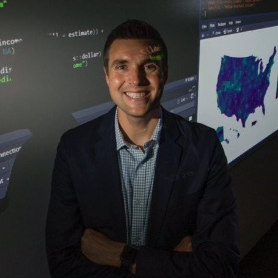

# Kyle Walker: spatial data science research & consulting

Welcome! I’m Kyle Walker, a spatial data science researcher, educator, and consultant. Here is some information about my current work:

- I am the author of the book [Analyzing US Census Data: Methods, Maps, and Models in R](https://walker-data.com/census-r/), which is free to read online and is forthcoming with CRC Press in 2022.
- I’m an R developer actively working on the following packages:
  - tidycensus, which helps R users get demographic & spatial data from the US Census Bureau ready-to-go for use in their analyses;
  - tigris, which downloads US Census Bureau spatial data and loads it directly into R as simple features objects;
  - mapboxapi, an R interface to [Mapbox web services](https://docs.mapbox.com/api/). Use the package to optimize routes, draw isochrones, read and write vector tiles, use custom Mapbox maps in Leaflet projects, and more;
  - crsuggest, which gives R users projected coordinate system suggestions for their spatial datasets.
- I’m an [academic](http://personal.tcu.edu/kylewalker/) researching [data science](https://magazine.tcu.edu/fall-2021/kyle-walker-open-source-mapping-tools/) and [visualization tools for spatial demography](http://personal.tcu.edu/kylewalker/immigrant-america/#11/41.8643/-87.6307). I’m currently teaching courses in [exploratory data analysis with Python](https://walker-data.com/geog30323) and [introductory Urban Studies](https://github.com/walkerke/urbanslides).
- I am Director of Research at a [boutique data science and strategy firm](https://www.linnaean.co/), where we use cutting-edge geospatial & machine learning methods to improve companies’ business outcomes.
- I also consult through my personal firm, Walker Data, where I work with individual clients and organizations to integrate tools like tidycensus into their workflows and to learn R and spatial data analysis.

If you are interested in working with me, send me a note at kyle@walker-data.com and let’s discuss your idea!